# DATA 624 Project 1 v1

CUNY Fall 2021

Philip Tanofsky

16 October 2021

```r
# Import required R libraries
library(fpp3)
library(tidyverse)
library(readxl)
```

This project consists of 3 parts - two required and one bonus and is worth 15% of your grade. The project is due at 11:59 PM on Sunday Apr 11. I will accept late submissions with a penalty until the meetup after that when we review some projects.

# Part A – ATM Forecast

- Dataset: ATM624Data.xlsx

In part A, I want you to forecast how much cash is taken out of 4 different ATM machines for May 2010. The data is given in a single file. The variable `Cash` is provided in hundreds of dollars, other than that it is straight forward. I am being somewhat ambiguous on purpose to make this have a little more business feeling. Explain and demonstrate your process, techniques used and not used, and your actual forecast. I am giving you data via an Excel file, please provide your written report on your findings, visuals, discussion and your R code via an RPubs link along with the actual.rmd file Also please submit the forecast which you will put in an Excel readable file.

```r
# Read in data
# xlsx_example <- readxl_example("datasets.xlsx")
atm_data_raw <- read_excel("data/ATM624Data.xlsx")

head(atm_data_raw)
```

```
## # A tibble: 6 × 3
##    DATE ATM    Cash
##   <dbl> <chr> <dbl>
## 1 39934 ATM1     96
## 2 39934 ATM2    107
## 3 39935 ATM1     82
## 4 39935 ATM2     89
## 5 39936 ATM1     85
## 6 39936 ATM2     90
```

```r
summary(atm_data_raw)
```

```
##       DATE           ATM                 Cash
##  Min.   :39934   Length:1474        Min.   :    0.0
##  1st Qu.:40026   Class :character   1st Qu.:    0.5
##  Median :40118   Mode  :character   Median :   73.0
##  Mean   :40118                      Mean   :  155.6
##  3rd Qu.:40210                      3rd Qu.:  114.0
##  Max.   :40312                      Max.   :10919.8
##                                     NA's   :19
```

```r
dim(atm_data_raw)
```

```
## [1] 1474    3
```

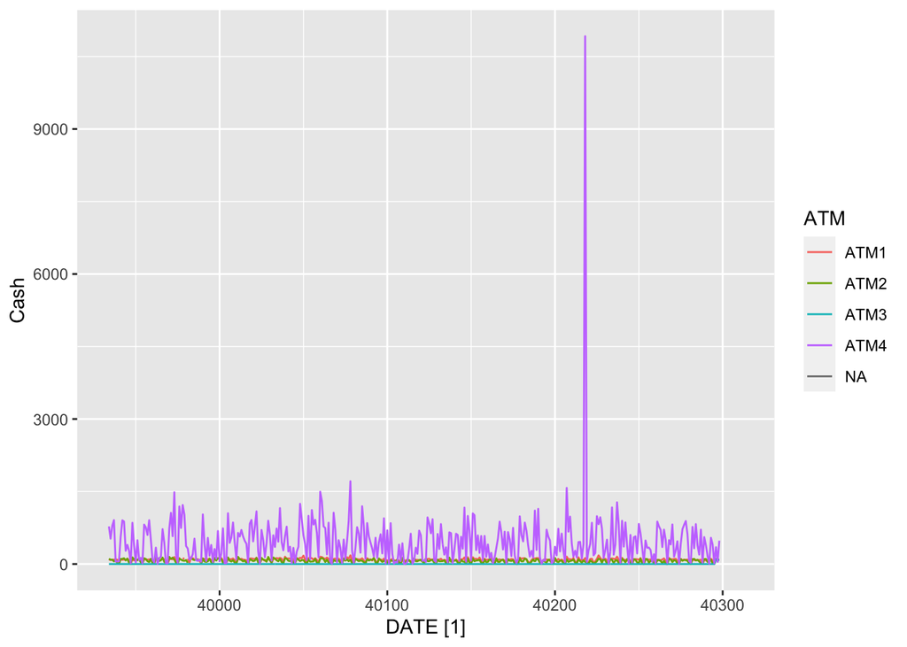

```r
# 1474    3
#Cash in hundreds

atm_data_ts <- atm_data_raw %>%
  as_tsibble(index = DATE, key = ATM)

atm_data_ts %>%
  autoplot(Cash)
```

```r
atm_data_ts %>% print(n = Inf)
```

```
## # A tsibble: 1,474 x 3 [1]
## # Key:       ATM [5]
##       DATE ATM       Cash
##      <dbl> <chr>    <dbl>
##    1 39934 ATM1     96
##    2 39935 ATM1     82
##    3 39936 ATM1     85
##    4 39937 ATM1     90
##    5 39938 ATM1     99
##    6 39939 ATM1     88
##    7 39940 ATM1      8
##    8 39941 ATM1    104
##    9 39942 ATM1     87
##   10 39943 ATM1     93
##   11 39944 ATM1     86
```

[output cut: 1463 more lines]

Summary output DATE ATM Cash  
Min. :39934 Length:1474 Min. : 0.0  
1st Qu.:40026 Class :character 1st Qu.: 0.5  
Median :40118 Mode :character Median : 73.0  
Mean :40118 Mean : 155.6  
3rd Qu.:40210 3rd Qu.: 114.0  
Max. :40312 Max. :10919.8  
NA’s :19

Date 39934 to 40312

379 dates

ATM1, ATM2, ATM3, ATM4, NA

Cash 19 NA’s

Dimensions output [1] 1474 3

# Part B – Forecasting Power

- Dataset: ResidentialCustomerForecastLoad-624.xlsx

Part B consists of a simple dataset of residential power usage for January 1998 until December 2013. Your assignment is to model these data and a monthly forecast for 2014. The data is given in a single file. The variable ‘KWH’ is power consumption in Kilowatt hours, the rest is straight forward. Add this to your existing files above.

# Part C – Waterflow (optional)

- Dataset: Waterflow_Pipe1.xlsx and Waterflow_Pipe2.xlsx